# Bellabeat: A Case Study (Leaf Tracker)

Jeanelfe Joy Delfinado

Jan 12, 2026

# The Business Task

Bellabeat wants to understand how users of other smart devices engage with activity, sleep, and wellness features so they can identify which behaviors are most relevant to Bellabeat customers. This analysis will help Bellabeat decide which user habits to highlight, support, or target in their marketing strategy for the Leaf.

# The Data

The data utilized is the FitBit Fitness Tracker Data from Kaggle. It is important to note the limitations: the dataset originates from 2016 and includes only 30 participants who consented to the study.

Since the Leaf product tracks activity, sleep, and stress, this case study focuses on daily movement and sleep patterns.

## Data Credibility & Integrity (ROCCC Analysis)

- **Reliability:** Low. The sample size is small (30-33 users) and demographic information (like gender) is missing.
- **Originality:** Low. This is third-party data collected via Amazon Mechanical Turk.
- **Comprehensiveness:** Medium. It covers activity, sleep, and heart rate, but lacks Bellabeat-specific metrics like menstrual cycle tracking.
- **Currentness:** Low. Data is from 2016 and may not reflect current wearable tech trends.
- **Citations:** Properly cited via Kaggle/Mobius.

# The Process

To ensure a reproducible and scalable analysis, I am using **R** for data transformation and visualization.

#### About this notebook

This case study follows a transparent workflow. All code is shown so recruiters, reviewers, or collaborators can understand the decisions made at each stage of the analysis.

## Loading Libraries

I will begin by loading the `tidyverse` for data manipulation, `lubridate` for handling date-time objects, and `janitor` for data cleaning.

```r
library(tidyverse)
library(lubridate)
library(janitor)
# The data sets that I will be using
activity <- read_csv("Case Study/Fitbase_Data_160412-160512/dailyActivity_merged.csv") %>% clean_names()
sleep <- read_csv("Case Study/Fitbase_Data_160412-160512/sleepDay_merged.csv") %>% clean_names()
```

## Data Cleaning and Transformation

### 1. Data inspection

For this part, I’ll be using `glimpse`

```r
glimpse(activity)
```

```
## Rows: 940
## Columns: 15
## $ id                         <dbl> 1503960366, 1503960366, 1503960366, 1503960…
## $ activity_date              <chr> "4/12/2016", "4/13/2016", "4/14/2016", "4/1…
## $ total_steps                <dbl> 13162, 10735, 10460, 9762, 12669, 9705, 130…
## $ total_distance             <dbl> 8.50, 6.97, 6.74, 6.28, 8.16, 6.48, 8.59, 9…
## $ tracker_distance           <dbl> 8.50, 6.97, 6.74, 6.28, 8.16, 6.48, 8.59, 9…
## $ logged_activities_distance <dbl> 0, 0, 0, 0, 0, 0, 0, 0, 0, 0, 0, 0, 0, 0, 0…
## $ very_active_distance       <dbl> 1.88, 1.57, 2.44, 2.14, 2.71, 3.19, 3.25, 3…
## $ moderately_active_distance <dbl> 0.55, 0.69, 0.40, 1.26, 0.41, 0.78, 0.64, 1…
## $ light_active_distance      <dbl> 6.06, 4.71, 3.91, 2.83, 5.04, 2.51, 4.71, 5…
## $ sedentary_active_distance  <dbl> 0, 0, 0, 0, 0, 0, 0, 0, 0, 0, 0, 0, 0, 0, 0…
## $ very_active_minutes        <dbl> 25, 21, 30, 29, 36, 38, 42, 50, 28, 19, 66,…
## $ fairly_active_minutes      <dbl> 13, 19, 11, 34, 10, 20, 16, 31, 12, 8, 27, …
## $ lightly_active_minutes     <dbl> 328, 217, 181, 209, 221, 164, 233, 264, 205…
## $ sedentary_minutes          <dbl> 728, 776, 1218, 726, 773, 539, 1149, 775, 8…
## $ calories                   <dbl> 1985, 1797, 1776, 1745, 1863, 1728, 1921, 2…
```

```r
glimpse(sleep)
```

```
## Rows: 413
## Columns: 5
## $ id                   <dbl> 1503960366, 1503960366, 1503960366, 1503960366, 1…
## $ sleep_day            <chr> "4/12/2016 12:00:00 AM", "4/13/2016 12:00:00 AM",…
## $ total_sleep_records  <dbl> 1, 2, 1, 2, 1, 1, 1, 1, 1, 1, 1, 1, 1, 1, 1, 1, 1…
## $ total_minutes_asleep <dbl> 327, 384, 412, 340, 700, 304, 360, 325, 361, 430,…
## $ total_time_in_bed    <dbl> 346, 407, 442, 367, 712, 320, 377, 364, 384, 449,…
```

### 2. Fixing date columns

```r
activity <- activity %>%
  mutate(activity_date = mdy(activity_date))

sleep <- sleep %>%
  mutate(sleep_day = as_date(mdy_hms(sleep_day)))
```

### 3. Merging two tables

```r
merged <- activity %>%
  inner_join(sleep, by = c("id", "activity_date" = "sleep_day"))
```

The merged dataset combines daily activity and sleep records per user per date, allowing a unified view of daily wellness behavior.

### 4. Checking if merge succeeded

```r
head(merged)
```

```
## # A tibble: 6 × 18
##           id activity_date total_steps total_distance tracker_distance
##        <dbl> <date>              <dbl>          <dbl>            <dbl>
## 1 1503960366 2016-04-12          13162           8.5              8.5
## 2 1503960366 2016-04-13          10735           6.97             6.97
## 3 1503960366 2016-04-15           9762           6.28             6.28
## 4 1503960366 2016-04-16          12669           8.16             8.16
## 5 1503960366 2016-04-17           9705           6.48             6.48
## 6 1503960366 2016-04-19          15506           9.88             9.88
## # ℹ 13 more variables: logged_activities_distance <dbl>,
## #   very_active_distance <dbl>, moderately_active_distance <dbl>,
## #   light_active_distance <dbl>, sedentary_active_distance <dbl>,
## #   very_active_minutes <dbl>, fairly_active_minutes <dbl>,
## #   lightly_active_minutes <dbl>, sedentary_minutes <dbl>, calories <dbl>,
## #   total_sleep_records <dbl>, total_minutes_asleep <dbl>,
## #   total_time_in_bed <dbl>
```

### 5. Checking and removing duplicates

```r
merged %>% get_dupes(id, activity_date)
```

```
## # A tibble: 6 × 19
##          id activity_date dupe_count total_steps total_distance tracker_distance
##       <dbl> <date>             <int>       <dbl>          <dbl>            <dbl>
## 1    4.39e9 2016-05-05             2        9603           7.38             7.38
## 2    4.39e9 2016-05-05             2        9603           7.38             7.38
## 3    4.70e9 2016-05-07             2       14370          11.6             11.6
## 4    4.70e9 2016-05-07             2       14370          11.6             11.6
## 5    8.38e9 2016-04-25             2       12405           9.84             9.84
## 6    8.38e9 2016-04-25             2       12405           9.84             9.84
## # ℹ 13 more variables: logged_activities_distance <dbl>,
## #   very_active_distance <dbl>, moderately_active_distance <dbl>,
## #   light_active_distance <dbl>, sedentary_active_distance <dbl>,
## #   very_active_minutes <dbl>, fairly_active_minutes <dbl>,
## #   lightly_active_minutes <dbl>, sedentary_minutes <dbl>, calories <dbl>,
## #   total_sleep_records <dbl>, total_minutes_asleep <dbl>,
## #   total_time_in_bed <dbl>
```

```r
merged <- merged %>% distinct()
```

```r
merged %>% get_dupes(id, activity_date)
```

```
## No duplicate combinations found of: id, activity_date
```

```
## # A tibble: 0 × 19
## # ℹ 19 variables: id <dbl>, activity_date <date>, dupe_count <int>,
## #   total_steps <dbl>, total_distance <dbl>, tracker_distance <dbl>,
## #   logged_activities_distance <dbl>, very_active_distance <dbl>,
## #   moderately_active_distance <dbl>, light_active_distance <dbl>,
## #   sedentary_active_distance <dbl>, very_active_minutes <dbl>,
## #   fairly_active_minutes <dbl>, lightly_active_minutes <dbl>,
## #   sedentary_minutes <dbl>, calories <dbl>, total_sleep_records <dbl>, …
```

## Summary

```r
summary(merged)
```

```
##        id            activity_date         total_steps    total_distance
##  Min.   :1.504e+09   Min.   :2016-04-12   Min.   :   17   Min.   : 0.010
##  1st Qu.:3.977e+09   1st Qu.:2016-04-19   1st Qu.: 5189   1st Qu.: 3.592
##  Median :4.703e+09   Median :2016-04-27   Median : 8913   Median : 6.270
##  Mean   :4.995e+09   Mean   :2016-04-26   Mean   : 8515   Mean   : 6.012
##  3rd Qu.:6.962e+09   3rd Qu.:2016-05-04   3rd Qu.:11370   3rd Qu.: 8.005
##  Max.   :8.792e+09   Max.   :2016-05-12   Max.   :22770   Max.   :17.540
##  tracker_distance logged_activities_distance very_active_distance
##  Min.   : 0.010   Min.   :0.0000             Min.   : 0.000
##  1st Qu.: 3.592   1st Qu.:0.0000             1st Qu.: 0.000
##  Median : 6.270   Median :0.0000             Median : 0.570
##  Mean   : 6.007   Mean   :0.1089             Mean   : 1.446
##  3rd Qu.: 7.950   3rd Qu.:0.0000             3rd Qu.: 2.360
##  Max.   :17.540   Max.   :4.0817             Max.   :12.540
##  moderately_active_distance light_active_distance sedentary_active_distance
##  Min.   :0.0000             Min.   :0.010         Min.   :0.0000000
##  1st Qu.:0.0000             1st Qu.:2.540         1st Qu.:0.0000000
##  Median :0.4200             Median :3.665         Median :0.0000000
##  Mean   :0.7439             Mean   :3.791         Mean   :0.0009268
##  3rd Qu.:1.0375             3rd Qu.:4.918         3rd Qu.:0.0000000
##  Max.   :6.4800             Max.   :9.480         Max.   :0.1100000
##  very_active_minutes fairly_active_minutes lightly_active_minutes
##  Min.   :  0.00      Min.   :  0.00        Min.   :  2.0
##  1st Qu.:  0.00      1st Qu.:  0.00        1st Qu.:158.0
##  Median :  9.00      Median : 11.00        Median :208.0
##  Mean   : 25.05      Mean   : 17.92        Mean   :216.5
##  3rd Qu.: 38.00      3rd Qu.: 26.75        3rd Qu.:263.0
##  Max.   :210.00      Max.   :143.00        Max.   :518.0
##  sedentary_minutes    calories    total_sleep_records total_minutes_asleep
##  Min.   :   0.0    Min.   : 257   Min.   :1.00        Min.   : 58.0
##  1st Qu.: 631.2    1st Qu.:1841   1st Qu.:1.00        1st Qu.:361.0
##  Median : 717.0    Median :2207   Median :1.00        Median :432.5
##  Mean   : 712.1    Mean   :2389   Mean   :1.12        Mean   :419.2
##  3rd Qu.: 782.8    3rd Qu.:2920   3rd Qu.:1.00        3rd Qu.:490.0
##  Max.   :1265.0    Max.   :4900   Max.   :3.00        Max.   :796.0
##  total_time_in_bed
##  Min.   : 61.0
##  1st Qu.:403.8
##  Median :463.0
##  Mean   :458.5
##  3rd Qu.:526.0
##  Max.   :961.0
```

```r
merged %>%
  summarise(sd_light = sd(lightly_active_minutes, na.rm = TRUE))
```

```
## # A tibble: 1 × 1
##   sd_light
##      <dbl>
## 1     86.7
```

Based on this summary, these are the insights I’ve gathered:

**Daily Activity Insights**

**Overall, users show moderate activity with high time spent sedentary and inconsistent sleep duration. Light activity dominates daily movement, suggesting lifestyle-driven wellness rather than workout-focused routines. These behavior patterns reveal opportunities for Bellabeat to support consistent movement and better sleep through targeted reminders and wellness-focused product messaging.**

# Analytical Questions

1. How does activity intensity relate to how long users sleep?
2. Are users consistent in their daily activity levels?
3. How often do users meet recommended sleep duration (7–9 hours)?
4. What movement patterns appear across the week?

## Activity-Sleep Correlation

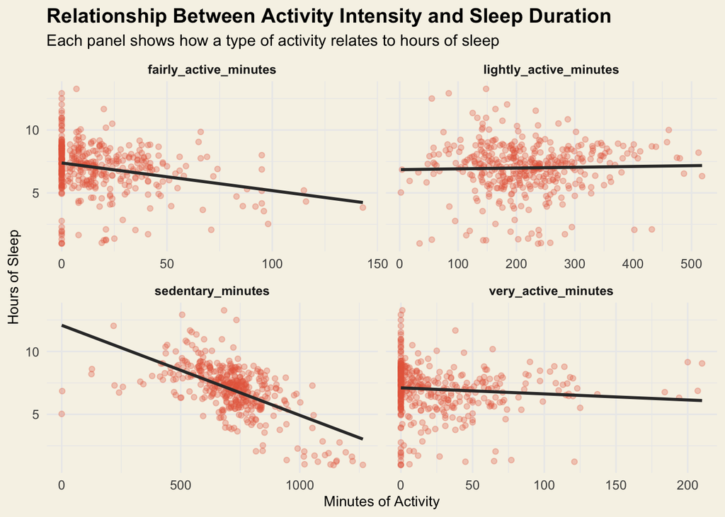

```r
# Correlation between type of activity and sleep
daily_activity_sleep <- merged %>%
  mutate(SleepHours = total_minutes_asleep / 60)

activity_sleep_long <- daily_activity_sleep %>%
  mutate(SleepHours = total_minutes_asleep / 60) %>%
  select(
    SleepHours,
    sedentary_minutes,
    lightly_active_minutes,
    fairly_active_minutes,
    very_active_minutes
  ) %>%
  pivot_longer(
    cols = -SleepHours,
    names_to = "activity_type",
    values_to = "minutes"
  )

ggplot(activity_sleep_long, aes(x = minutes, y = SleepHours)) +
  geom_point(alpha = 0.3, color = "#e5664a") +
  geom_smooth(method = "lm", se = FALSE, color = "#343434") +
  facet_wrap(~ activity_type, scales = "free_x") +
  labs(
    title = "Relationship Between Activity Intensity and Sleep Duration",
    subtitle = "Each panel shows how a type of activity relates to hours of sleep",
    x = "Minutes of Activity",
    y = "Hours of Sleep"
  ) +
  theme_minimal() +
  theme(
    plot.title = element_text(face = "bold", size = 14),
    axis.title = element_text(size = 10),
    axis.text = element_text(size = 9),
    strip.text = element_text(face = "bold"),

    # 👇 THESE control the background
    panel.background = element_rect(fill = "#f6f3e8", color = NA),
    plot.background  = element_rect(fill = "#f6f3e8", color = NA),
    strip.background = element_rect(fill = "#f6f3e8", color = NA)
  )
```

Sleep is driven more by lifestyle balance and inactivity reduction than by exercise intensity.

## Consistency of Daily Behaviors

```r
# Measuring Consistency using Standard Deviation
activity_stats <- merged %>%
  summarise(
    mean_steps = mean(total_steps, na.rm = TRUE),
    sd_steps = sd(total_steps, na.rm = TRUE),
    cv_steps = sd_steps / mean_steps,

    mean_light = mean(lightly_active_minutes, na.rm = TRUE),
    sd_light = sd(lightly_active_minutes, na.rm = TRUE),
    cv_light = sd_light / mean_light,

    mean_fair = mean(fairly_active_minutes, na.rm = TRUE),
    sd_fair = sd(fairly_active_minutes, na.rm = TRUE),
    cv_fair = sd_fair / mean_fair,

    mean_very = mean(very_active_minutes, na.rm = TRUE),
    sd_very = sd(very_active_minutes, na.rm = TRUE),
    cv_very = sd_very / mean_very,

    mean_sedentary = mean(sedentary_minutes, na.rm = TRUE),
    sd_sedentary = sd(sedentary_minutes, na.rm = TRUE),
    cv_sedentary = sd_sedentary / mean_sedentary
  ) %>%
  pivot_longer(
    cols = everything(),
    names_to = c("metric", "category"),
    names_sep = "_",
    values_to = "value"
  ) %>%
  pivot_wider(
    names_from = metric,
    values_from = value
  )

activity_stats
```

```
## # A tibble: 5 × 4
##   category    mean     sd    cv
##   <chr>      <dbl>  <dbl> <dbl>
## 1 steps     8515.  4157.  0.488
## 2 light      217.    86.7 0.400
## 3 fair        17.9   22.4 1.25
## 4 very        25.0   36.2 1.45
## 5 sedentary  712.   166.  0.233
```

The coefficient of variation reveals that users are highly inconsistent in moderate and vigorous activity (CV = 1.25–1.44), indicating that structured exercise is not a regular habit. Light activity and steps show moderate variability, reflecting lifestyle-driven movement rather than planned workouts. Sedentary time is the most consistent behavior (CV = 0.23), suggesting prolonged inactivity is a stable part of users’ daily routines.

**These patterns highlight a strong opportunity for Bellabeat to focus on small-movement encouragement, sedentary reduction, and holistic wellness rather than high-intensity fitness content.**

Bar chart of Coefficient of Variation (CV)

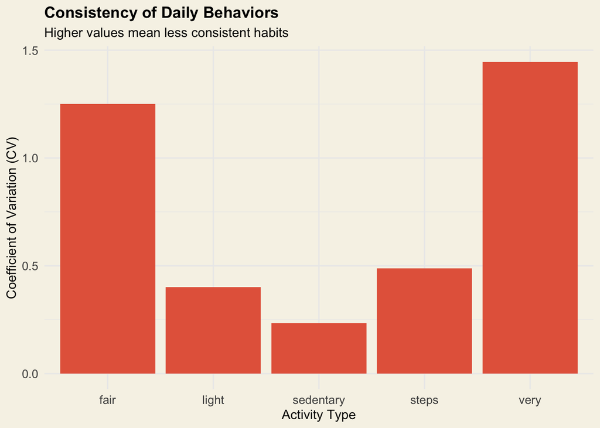

```r
ggplot(activity_stats, aes(x = category, y = cv)) +
  geom_col(fill = "#e5664a") +
  labs(
    title = "Consistency of Daily Behaviors",
    subtitle = "Higher values mean less consistent habits",
    x = "Activity Type",
    y = "Coefficient of Variation (CV)",
    color = "#343434"
  ) +
  theme_minimal() +
  theme(
    plot.title = element_text(face = "bold"),
    axis.text = element_text(size = 10),

     panel.background = element_rect(fill = "#f6f3e8", color = NA),
    plot.background  = element_rect(fill = "#f6f3e8", color = NA),
    strip.background = element_rect(fill = "#f6f3e8", color = NA)
  )
```

## Meeting the Recommended Sleep

```r
# Percentage of users that meet the recommended sleep
merged %>%
  summarise(
    pct_meet_sleep = mean(total_minutes_asleep >= 420 & total_minutes_asleep <= 540) * 100
  )
```

```
## # A tibble: 1 × 1
##   pct_meet_sleep
##            <dbl>
## 1           46.3
```

**A 46% sleep compliance rate suggests:**

- users struggle with regular routines
- sleep may be influenced by stress, work hours, or inconsistent lifestyle
- bedtime consistency is weak
- recovery habits are unstable

**Since recommended sleep is achieved less than half the time, Bellabeat can create campaigns around “small steps toward better sleep,” highlighting micro-habits (earlier wind-down, reduced screen time) supported by the Leaf.**

How Often Users Meet Recommended Sleep

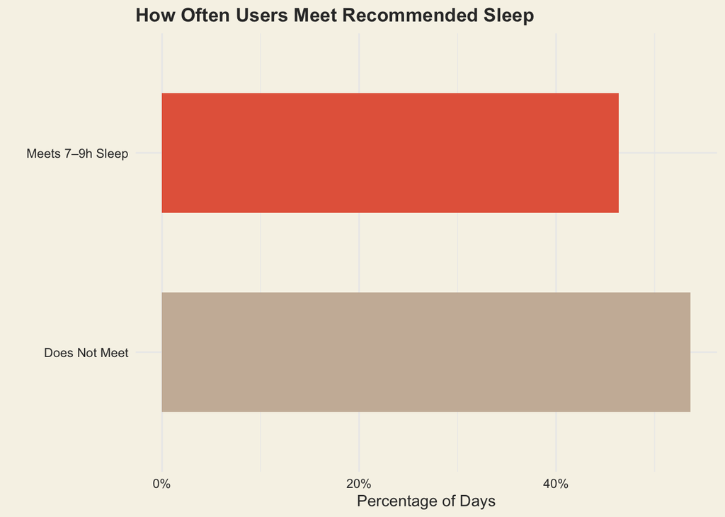

```r
sleep_pct <- data.frame(
  status = c("Meets 7–9h Sleep", "Does Not Meet"),
  percent = c(46.34, 100 - 46.34)
)

ggplot(sleep_pct, aes(x = status, y = percent, fill = status)) +
  geom_col(width = 0.6) +
  coord_flip() +
  scale_y_continuous(labels = scales::percent_format(scale = 1)) +
  scale_fill_manual(values = c(
    "Meets 7–9h Sleep" = "#e5664a",
    "Does Not Meet"   = "#cbb8a6"
  )) +
  labs(
    title = "How Often Users Meet Recommended Sleep",
    x = "",
    y = "Percentage of Days"
  ) +
  theme_minimal() +
  theme(
    legend.position = "none",
    plot.background = element_rect(fill = "#f6f3e8", color = NA),
    panel.background = element_rect(fill = "#f6f3e8", color = NA),
    text = element_text(color = "#343434"),
    axis.text = element_text(color = "#343434"),
    axis.title = element_text(color = "#343434"),
    plot.title = element_text(face = "bold")
  )
```